# Assignment05 QUANT

Jessica Tang

10/08/2020

## Libraries

```r
library(tidyverse)
library(jtools)
library(interactions)
library(knitr)
library(huxtable)
```

## Note

- The requirements of the assignment are fulfilled in the models I ran to estimate HCPIP. Everything else is additional models I ran to try to look at Housing Cost (HC) and HINCP (Household Income) on their own, before they become HC/HINCP = HCPIP (Housing Cost as a Percentage of Household Income).

## Data

```r
all_hh <- read_csv("all_hh.csv") %>%
  filter(HINCP > 0,
         HINCP <= 200000,
         !TEN_label == "Occupied without payment of rent",
         !TEN_label == "N/A (GQ/vacant") %>%
  rename(TEN = TEN_label,
       FS = FS_label,
       LNGI = LNGI_label,
       BUR = Burdened) %>%
  mutate(TEN = case_when(TEN == "Owned with mortgage or loan (include home equity loans)" ~ "Owned w. mortgage or loan",
                         TEN == "Rented" ~ "Rented",
                         TEN == "Owned free and clear" ~ "Owned fc"),
         LNGI = case_when(LNGI == "At least one person in the household 14 and over speaks English only or speaks English 'very well'" ~ "At least 1",
                          LNGI == "No one in the household 14 and over speaks English only or speaks English 'very well'" ~ "No one"))
```

**Variables**

Continuous

- HINCP = Household Income
- HC = Housing Cost (original variables GRNTP and SMOCP mutated to be HC)
- HCPIP = Housing Cost as a Percentage of Household Income (original variables GRPIP and OCPIP mutated to be HCPIP)
- NP = Number of People in Household

Categorical

- TEN = Tenure
- FS = Food Stamps
- LNGI = Language Ability
- BUR = Burdened or not (a variable I made up from an earlier assignment)

## Research Questions

- Does Housing Cost as a Percentage of Income change for more for rented households on food stamps or owner households on food stamps than for owner free and clear households not on food stamps? (Do Tenure and Food Stamps together have an interactive effect on HCPIP?)
- Do Households with no English-language ability AND on Food Stamps experience a different HCPIP than Households with English-language ability AND not on Food Stamps?
- As the Number of People in Households vary along with whether they are on Food Stamps, how does the HCPIP change?

## Basic Linear Reg. Model

### Model 1

This is the same linear regression model, Model 1, from Assignment04.

```r
model1 <- lm(HCPIP ~ TEN + FS + LNGI + NP,
             data = all_hh)

summary(model1)
```

```
##
## Call:
## lm(formula = HCPIP ~ TEN + FS + LNGI + NP, data = all_hh)
##
## Residuals:
##     Min      1Q  Median      3Q     Max
## -58.697 -14.385  -6.904   6.412  86.738
##
## Coefficients:
##                              Estimate Std. Error t value Pr(>|t|)
## (Intercept)                  20.75141    0.15138  137.09   <2e-16 ***
## TENOwned w. mortgage or loan 12.85463    0.15532   82.76   <2e-16 ***
## TENRented                    17.56021    0.16201  108.39   <2e-16 ***
## FSYes                        14.31792    0.17713   80.83   <2e-16 ***
## LNGINo one                   11.14919    0.24988   44.62   <2e-16 ***
## NP                           -1.08159    0.03338  -32.41   <2e-16 ***
## ---
## Signif. codes:  0 '***' 0.001 '**' 0.01 '*' 0.05 '.' 0.1 ' ' 1
##
## Residual standard error: 23.53 on 156828 degrees of freedom
## Multiple R-squared:  0.1489, Adjusted R-squared:  0.1488
## F-statistic:  5486 on 5 and 156828 DF,  p-value: < 2.2e-16
```

## HCPIP Models: Interaction Terms

### Model 2: FS

```r
# FS (Food Stamps) as interaction term.

model2 <- lm(HCPIP ~ TEN + FS + LNGI + NP +
               TEN:FS + LNGI:FS + NP:FS,
            data = all_hh)

summary(model2)
```

```
##
## Call:
## lm(formula = HCPIP ~ TEN + FS + LNGI + NP + TEN:FS + LNGI:FS +
##     NP:FS, data = all_hh)
##
## Residuals:
##     Min      1Q  Median      3Q     Max
## -55.161 -14.357  -6.927   6.351  86.165
##
## Coefficients:
##                                    Estimate Std. Error t value Pr(>|t|)
## (Intercept)                        20.97327    0.16396 127.914  < 2e-16 ***
## TENOwned w. mortgage or loan       12.49550    0.16196  77.153  < 2e-16 ***
## TENRented                          16.25136    0.17406  93.366  < 2e-16 ***
## FSYes                               9.74053    0.51768  18.816  < 2e-16 ***
## LNGINo one                         13.98064    0.30052  46.522  < 2e-16 ***
## NP                                 -1.02301    0.03911 -26.159  < 2e-16 ***
## TENOwned w. mortgage or loan:FSYes  4.24496    0.57892   7.333 2.27e-13 ***
## TENRented:FSYes                     9.03274    0.49633  18.199  < 2e-16 ***
## FSYes:LNGINo one                   -9.55179    0.53969 -17.699  < 2e-16 ***
## FSYes:NP                           -0.24310    0.07485  -3.248  0.00116 **
## ---
## Signif. codes:  0 '***' 0.001 '**' 0.01 '*' 0.05 '.' 0.1 ' ' 1
##
## Residual standard error: 23.48 on 156824 degrees of freedom
## Multiple R-squared:  0.1523, Adjusted R-squared:  0.1522
## F-statistic:  3130 on 9 and 156824 DF,  p-value: < 2.2e-16
```

### **Model 3: TEN**

```r
# TEN (Tenure) as interaction term.

model3 <- lm(HCPIP ~ TEN + FS + LNGI + NP +
               FS:TEN + LNGI:TEN + NP:TEN,
            data = all_hh)

summary(model3)
```

```
##
## Call:
## lm(formula = HCPIP ~ TEN + FS + LNGI + NP + FS:TEN + LNGI:TEN +
##     NP:TEN, data = all_hh)
##
## Residuals:
##     Min      1Q  Median      3Q     Max
## -57.647 -14.495  -6.879   6.505  90.080
##
## Coefficients:
##                                         Estimate Std. Error t value Pr(>|t|)
## (Intercept)                             24.38512    0.23957 101.788  < 2e-16 ***
## TENOwned w. mortgage or loan             6.34071    0.31861  19.901  < 2e-16 ***
## TENRented                               14.26657    0.31011  46.005  < 2e-16 ***
## FSYes                                    9.72673    0.45002  21.614  < 2e-16 ***
## LNGINo one                              10.31621    0.63596  16.221  < 2e-16 ***
## NP                                      -2.24423    0.07517 -29.857  < 2e-16 ***
## TENOwned w. mortgage or loan:FSYes       1.02165    0.58440   1.748   0.0804 .
## TENRented:FSYes                          7.18876    0.50276  14.299  < 2e-16 ***
## TENOwned w. mortgage or loan:LNGINo one 13.08488    0.85158  15.365  < 2e-16 ***
## TENRented:LNGINo one                    -2.95515    0.70655  -4.182 2.89e-05 ***
## TENOwned w. mortgage or loan:NP          1.93643    0.09208  21.030  < 2e-16 ***
## TENRented:NP                             0.96275    0.09125  10.550  < 2e-16 ***
## ---
## Signif. codes:  0 '***' 0.001 '**' 0.01 '*' 0.05 '.' 0.1 ' ' 1
##
## Residual standard error: 23.42 on 156822 degrees of freedom
## Multiple R-squared:  0.1565, Adjusted R-squared:  0.1565
## F-statistic:  2646 on 11 and 156822 DF,  p-value: < 2.2e-16
```

### Model 4: LNGI

```r
# LNGI (Language Ability) as interaction term.

model4 <- lm(HCPIP ~ TEN + FS + LNGI + NP +
               TEN:LNGI + FS:LNGI + NP:LNGI,
            data = all_hh)

summary(model4)
```

```
##
## Call:
## lm(formula = HCPIP ~ TEN + FS + LNGI + NP + TEN:LNGI + FS:LNGI +
##     NP:LNGI, data = all_hh)
##
## Residuals:
##     Min      1Q  Median      3Q     Max
## -56.532 -14.430  -6.758   6.392  86.989
##
## Coefficients:
##                                         Estimate Std. Error t value Pr(>|t|)
## (Intercept)                             20.90716    0.15507 134.823  < 2e-16 ***
## TENOwned w. mortgage or loan            12.54332    0.15759  79.594  < 2e-16 ***
## TENRented                               17.82151    0.16641 107.091  < 2e-16 ***
## FSYes                                   15.09430    0.18775  80.394  < 2e-16 ***
## LNGINo one                              10.11722    0.71274  14.195  < 2e-16 ***
## NP                                      -1.14941    0.03466 -33.159  < 2e-16 ***
## TENOwned w. mortgage or loan:LNGINo one 12.70268    0.87617  14.498  < 2e-16 ***
## TENRented:LNGINo one                    -1.31252    0.72881  -1.801 0.071718 .
## FSYes:LNGINo one                        -6.37024    0.55719 -11.433  < 2e-16 ***
## LNGINo one:NP                            0.41799    0.12669   3.299 0.000969 ***
## ---
## Signif. codes:  0 '***' 0.001 '**' 0.01 '*' 0.05 '.' 0.1 ' ' 1
##
## Residual standard error: 23.48 on 156824 degrees of freedom
## Multiple R-squared:  0.1529, Adjusted R-squared:  0.1528
## F-statistic:  3144 on 9 and 156824 DF,  p-value: < 2.2e-16
```

### Model 5: NP

```r
model5 <- lm(HCPIP ~ TEN + FS + LNGI + NP +
               TEN:NP + FS:NP + LNGI:NP,
             data = all_hh)

# Just going to print the (adjusted) R-squared value for this one.
summary(model5)$adj.r.squared
```

```
## [1] 0.1518261
```

### **Model Fit**

Thanks to Carole’s tutorial for this code.

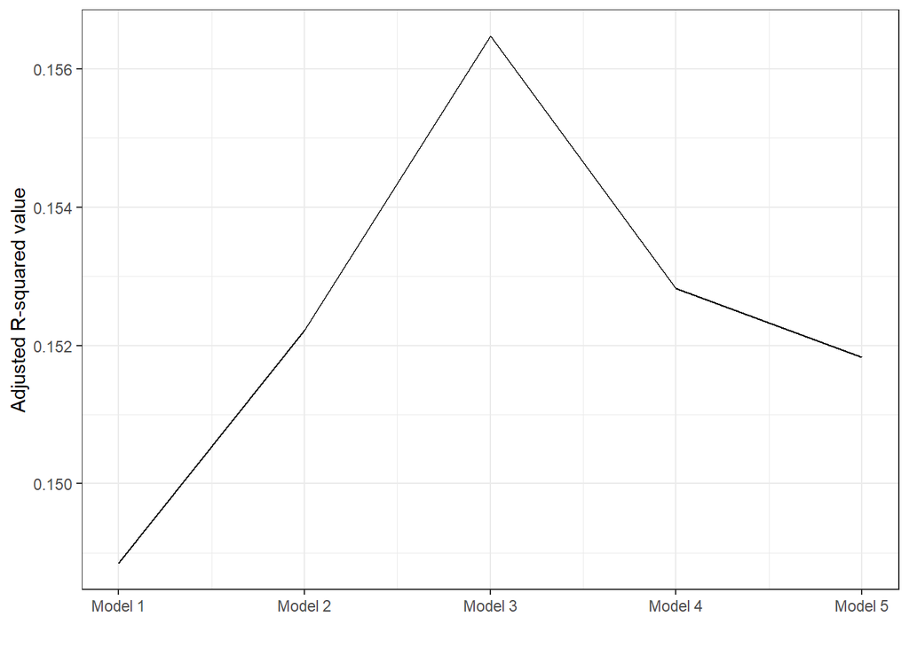

```r
ModelFit <- tibble(model = c(1, 2, 3, 4, 5),
                   R_square = c(summary(model1)$adj.r.squared,
                                summary(model2)$adj.r.squared,
                                summary(model3)$adj.r.squared,
                                summary(model4)$adj.r.squared,
                                summary(model5)$adj.r.squared))

ggplot(ModelFit, aes(x = model, y = R_square)) +
  geom_line() +
  scale_x_continuous(name = "",
                     breaks = breaks <- seq(1, 5, by = 1),
                     labels = paste("Model", breaks)) +
  scale_y_continuous(name = "Adjusted R-squared value") +
  theme_bw()
```

## **HCPIP Model 3b: Log Trans.**

**Model 3** is the best-fitting model so far. Now I will try to add a log transformation to Number of People in Household (NP) to see if I can get an even better fit.

```r
model3b <- lm(HCPIP ~ TEN + FS + LNGI + log(NP) +
               FS:TEN + LNGI:TEN + log(NP):TEN,
            data = all_hh)

summary(model3b)
```

```
##
## Call:
## lm(formula = HCPIP ~ TEN + FS + LNGI + log(NP) + FS:TEN + LNGI:TEN +
##     log(NP):TEN, data = all_hh)
##
## Residuals:
##     Min      1Q  Median      3Q     Max
## -59.583 -14.491  -6.704   6.347  90.620
##
## Coefficients:
##                                         Estimate Std. Error t value Pr(>|t|)
## (Intercept)                              25.5860     0.2319 110.325  < 2e-16 ***
## TENOwned w. mortgage or loan              7.5257     0.3284  22.917  < 2e-16 ***
## TENRented                                13.7571     0.3039  45.272  < 2e-16 ***
## FSYes                                     9.7876     0.4459  21.950  < 2e-16 ***
## LNGINo one                               10.1794     0.6339  16.058  < 2e-16 ***
## log(NP)                                  -8.4866     0.2269 -37.402  < 2e-16 ***
## TENOwned w. mortgage or loan:FSYes        1.4710     0.5791   2.540   0.0111 *
## TENRented:FSYes                           7.0486     0.4979  14.158  < 2e-16 ***
## TENOwned w. mortgage or loan:LNGINo one  13.3432     0.8487  15.722  < 2e-16 ***
## TENRented:LNGINo one                     -2.7755     0.7043  -3.941 8.13e-05 ***
## TENOwned w. mortgage or loan:log(NP)      5.4400     0.2933  18.551  < 2e-16 ***
## TENRented:log(NP)                         3.6607     0.2803  13.059  < 2e-16 ***
## ---
## Signif. codes:  0 '***' 0.001 '**' 0.01 '*' 0.05 '.' 0.1 ' ' 1
##
## Residual standard error: 23.35 on 156822 degrees of freedom
## Multiple R-squared:  0.1618, Adjusted R-squared:  0.1617
## F-statistic:  2751 on 11 and 156822 DF,  p-value: < 2.2e-16
```

### Model Fit2

I tried to do a different visualization, not very effectively… but just showing that Model 3b has a better adjusted R-squared value than Model 3 does. So the log transformation on NP was helpful.

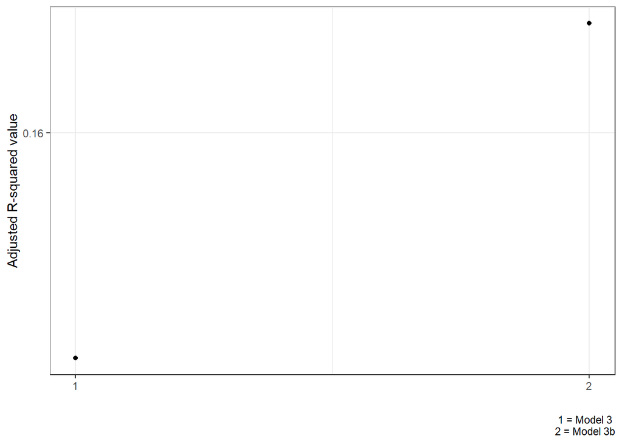

```r
ModelFit2 <- tibble(model = c(1, 2),
                   R_square = c(summary(model3)$adj.r.squared,
                                summary(model3b)$adj.r.squared))

ggplot(ModelFit2) +
  geom_point(aes(x = model, y = R_square)) +
  scale_x_continuous(name = "",
                     breaks = seq(0, 2, by=1)) +
  scale_y_continuous(name = "Adjusted R-squared value",
                     breaks = seq(0, 0.16, by = 0.010)) +
  labs(caption = "1 = Model 3 \n2 = Model 3b")+
  theme_bw()
```

### **Neat Table**

Thanks to Carole’s tutorial for this code. This table compares the very first model–a basic linear regression– with Model 3b, which has a log transformation on NP (Number of People in Household) and TEN (Tenure) as an interaction term.

```r
coeff_names <- c("Own w. mortgage" = "TENOwned w. mortgage or loan",
                 "Rent" = "TENRented",
                 "On Food Stamps" = "FSYes",
                 "No English ability" = "LNGINo one",
                 "# of People" = "NP",
                 "# of People (log)" = "log(NP)",
                 "Interaction: \nmortgage and food stamps" = "TENOwned w. mortgage or loan:FSYes",
                 "Interaction: \nrented and food stamps" = "TENRented:FSYes",
                 "Interaction: \nmortgage and no English ability" = "TENOwned w. mortgage or loan:LNGINo one",
                 "Interaction: \nrented and no English ability" = "TENRented:LNGINo one",
                 "Interaction: mortgage and # of People (log)" = "TENOwned w. mortgage or loan:log(NP)",
                 "Interaction: rented and # of People (log)" = "TENRented:log(NP)")


export_summs(model1, model3b,
             error_format = "(p = {p.value})",
             error_pos = "same",
             model.names = c("Model 1", "Model 3b"),
             coefs =  coeff_names)
```

|  | Model 1 | Model 3b |
| --- | --- | --- |
| Own w. mortgage | 12.85 *** (p = 0.00) | 7.53 *** (p = 0.00) |
| Rent | 17.56 *** (p = 0.00) | 13.76 *** (p = 0.00) |
| On Food Stamps | 14.32 *** (p = 0.00) | 9.79 *** (p = 0.00) |
| No English ability | 11.15 *** (p = 0.00) | 10.18 *** (p = 0.00) |
| # of People | -1.08 *** (p = 0.00) |  |
| # of People (log) |  | -8.49 *** (p = 0.00) |
| Interaction: mortgage and food stamps |  | 1.47 * (p = 0.01) |
| Interaction: rented and food stamps |  | 7.05 *** (p = 0.00) |
| Interaction: mortgage and no English ability |  | 13.34 *** (p = 0.00) |
| Interaction: rented and no English ability |  | -2.78 *** (p = 0.00) |
| Interaction: mortgage and # of People (log) |  | 5.44 *** (p = 0.00) |
| Interaction: rented and # of People (log) |  | 3.66 *** (p = 0.00) |
| N | 156834 | 156834 |
| R2 | 0.15 | 0.16 |
| *** p < 0.001; ** p < 0.01; * p < 0.05. |  |  |